# Praca domowa nr 5

Bogdan Jastrzębski

20 listopada 2018

# Wstęp

Niniejsza praca dotyczy sprawdzenia nieczytelności wykresów, które wprowadzają w błąd czytającego wykres. Sprawdzę, czy uzasadnione są przeciwwskazania na temat wykorzystywania wykresów 3D, w tym przypadku słupków.

# Nieczytelny wykres

Oto wykres przygotowany w LibreOffice Calc bez przeróbek. Został on wygenerowany automatycznie na podstawie tabeli. Ten fakt w połączeniu z wynikami ankiety powinien dawać do myślenia.

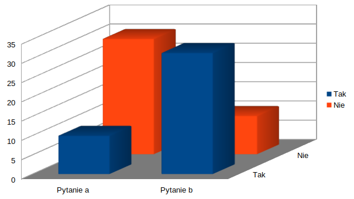

# Ankieta

W ankiecie wzięło udział 21 osób. Jest to na pewno mała grupa kontrolna, ale może uda nam się wyciągnąć pewne wnioski. Ankieta: https://docs.google.com/forms/d/e/1FAIpQLScPte_5qM4kZmFwBKmwogrxUS_hi6fAi4e63BX2IkQS3x-zhg/viewform?usp=sf_link

# Wyniki

## Pytanie 1 (Tak a)

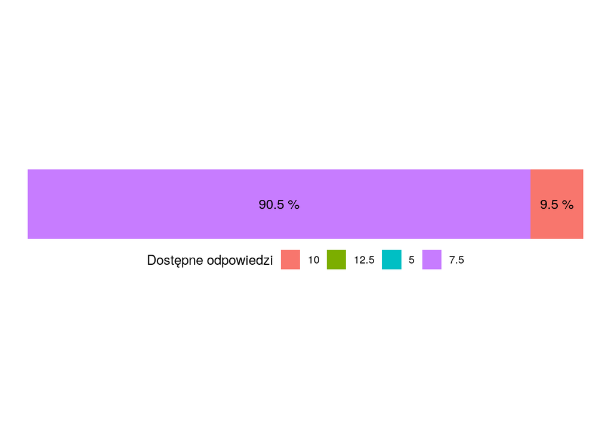

Odpowiedzią prawidłową jest 10, a więc tylko 9.5% uczestników odpowiedziało prawidłowo. Właściwie jest to najprostszy z czterech słupków do odczytania. Mimo tego, że znajduje się niedaleko podziałki, ma większy błąd, niż wykres obok:

## Pytanie 2 (Tak b)

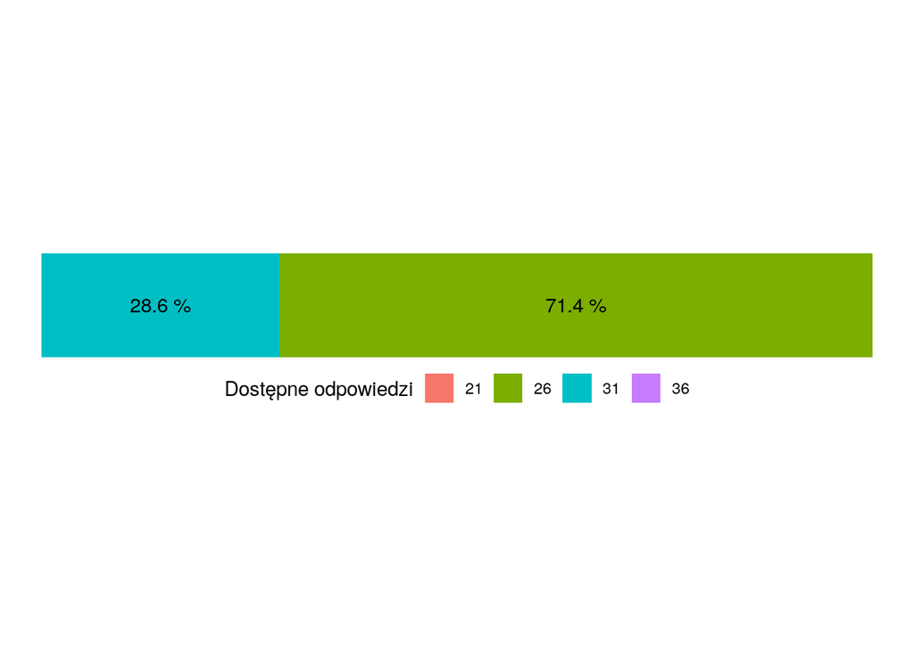

Prawidłowa odpowiedź w tym przypadku to 31. Ciekawostką na temat tego wykresu jest to, że został odczytany lepiej, niż poprzedni. Jednakże nadal 70% to błędne odpowiedzi, a różnica między preferowaną i prawidłową jest duża, bo aż 5:30.

## Pytanie 3

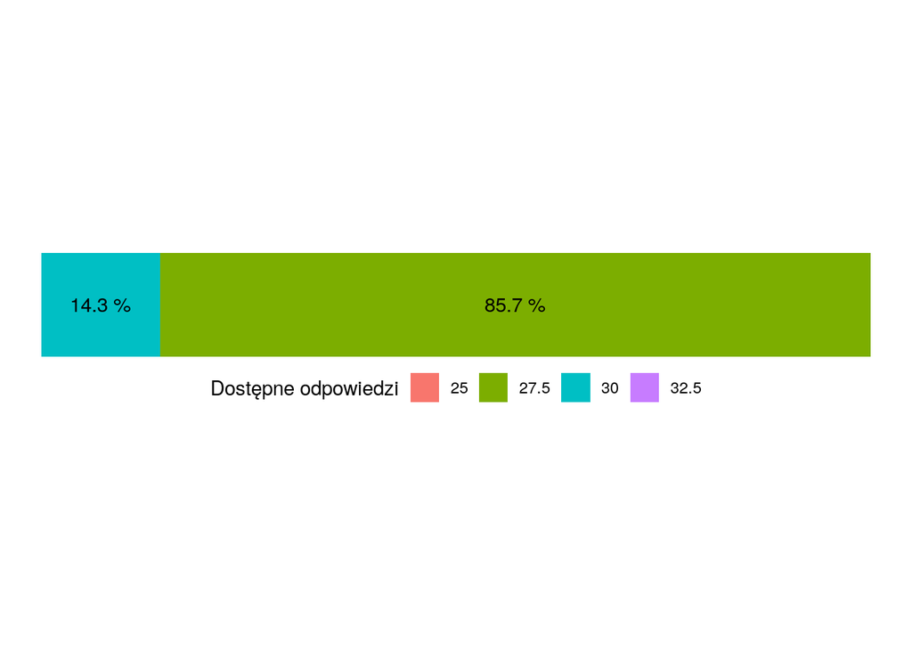

Poprawna odpowiedź: 30. Tutaj ponownie widać ogrom błędu popełnianego przez użytkowników. W poprzednim pytaniu słupek (Tak b) miałby mieć dla większości wysokość 26, ten natomiast 27.5. W rzeczywistości różnica między ich wysokościami rzeczywiście wynosi 1-1.5, ale słupek (Nie a) jest niższy od (Tak b). I gdyby ktoś się zastanowił, to stałoby się to oczywiste.

## Pytanie 4

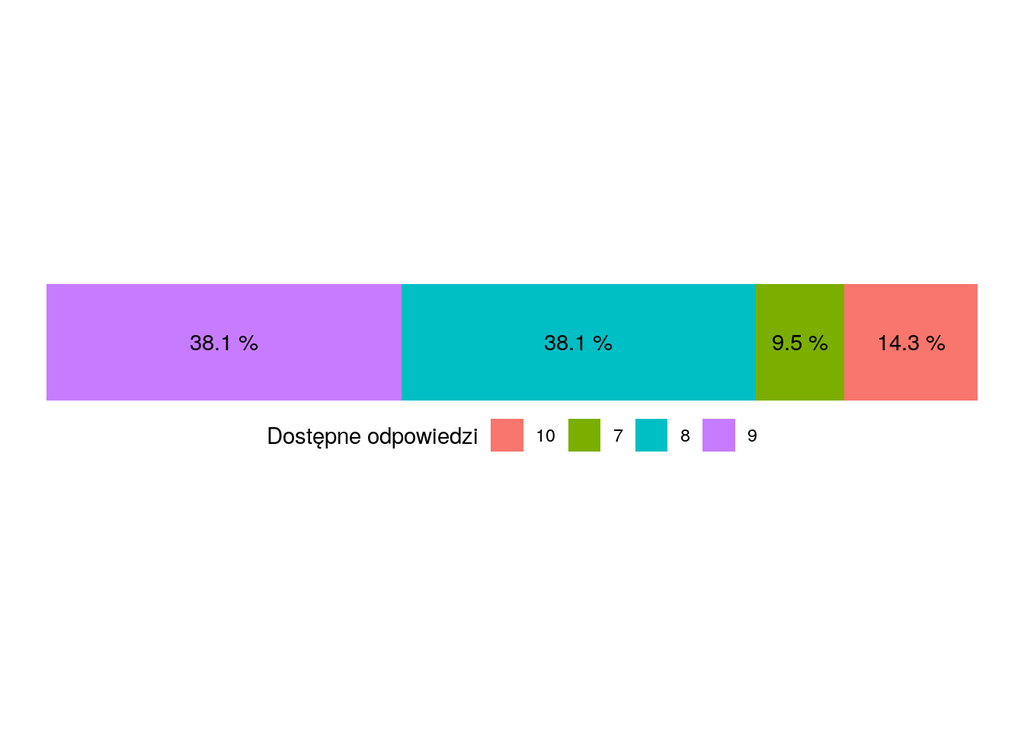

Prawidłowa odpowiedź: 10. Błąd wynosi tyle samo, co poprzednio, bo tylko 15% odpowiedziało poprawnie. W tym przypadku sprawa miała się inaczej niż w pozostałych pytaniach, bo zakres odpowiedzi jest mniejszy. Dalej jednak wiele osób zaznaczyło odpowiedź 9. W odniesieniu do pytania 1, w którym słupek jest równy słupkowi (Nie b), zauważmy, że gdyby wszystkie osoby, które zaznaczyły odpowiedź 9 zaokrągliły prawidłowo do 10, a nie do 7.5 to błąd w pytaniu 1 byłby niższy. Nie stało się tak jednak.

# Podsumowanie

Ważnym tutaj jest fakt, że wykres został wygenerowany automatycznie. Można powiedzieć, zupełnie przypadkowo, korzystając z szablonu wyprodukowaliśmy wykres, który w rekordowy sposób, moim zdaniem, wprowadza w bład.